# Comparison of results

24 enero, 2019

Las tablas a continuación presentan las diferencias entre los resultados reportados en el manuscrito y los resultados actualizados (20190112). La actualización incluye: (a) el uso de la nueva base de datos (n = 387); (b) el manejo de casos perdidos mediante imputación múltiple; (c) y el uso de variables de control en los modelos mediacionales. Se incluyen resultados de los análisis con y sin la sintomatología de PTSD en T0 como predictor

# 1 Materials and methods

## 1.1 Design

[output not shown]

## 1.2 Participants

| Original results | Updated results |
| --- | --- |
| Participants were 57 adults… | 187 |
| (35 female and 22 male) | (124 female and 63 male) |
| The mean age was 46.79 (SD=17.21) | 43.19, 14.88 |
| and the mean years of education 12.09 (SD = 3.82) | 12.36, 3.50 |
| 29.82% (17) were having a serious, severe or very painful medical problem; also | 20.77 (38) |
| 29.82% (17) received in a violent manner the news of family member, or other loved one, that died or was gravely injured; | 26.78 (49) |
| 26.32% (15) had been in a vehicle accident or other type of accident; | 22.40 (41) |
| 3.51% (2) witness grave injury, and | 13.11 (24) |
| 10.53% (6) had another type of traumatic experience. | 16.94 (31) |

# 2 Results

## 2.1 Descriptive

¿Estos resultados deben reflejar a la muestra total (n=387) o a la submuestra utilizada para el análisis mediacional (n = 187)?

| Original results | Updated results |
| --- | --- |
| The mean peritraumatic dissociation score during the last traumatic event was 22.33 (SD=11.41), which is considered significant dissociation (Marmar et al., 1997; Birmes et al., 2005). | 22.68, 10.72 |
| The mean reported peritraumatic distress during the last traumatic event was 24.48 (SD=13.05), considered significant distress (Brunet et al., 2001; Jehel, Brunet, Paterniti & Guelfi, 2005) | 23.66, 12.93 |
| and the mean traumatic load (i.e., number of traumatic events experienced before the last traumatic event) was 3.11 (SD=2.12). | 2.70, 2.08 |
| The most commonly reported previous traumatic experiences were: unexpected death of a family member or loved one (72%), | Pending |
| transportation accident (37%), | Pending |
| serious threat or injury to a family member or loved one (35%), | Pending |
| being the victim of aggression (28%), | Pending |
| almost drowning (26%), | Pending |
| and being in an industrial or work accident (23%). | Pending |
| In addition, the mean score for perceived social support was 33.37 (SD=10.62), | 33.76, 10.26 |
| and the mean PTSD symptomatology score at T1 was 39.53 (SD=16.23). | 39.08, 16.91 |
| Out of the complete sample, 26 individuals (45.61%) met criteria for PTSD one month after the traumatic event, | 41 (27.15 %) |
| and 31 (54.39%) did not. | 110 (72.85 %) |

## 2.2 Predicting Peritraumatic Dissociation

### 2.2.1 Correlations

Sugiero utilizar el coeficiente de correlación de Kendall, en vista de que la mayoría de las variables no poseen una distribución normal.

```
## [[1]]
##     varNames corType estimate p.value
## cor   t0_age Pearson     0.10     .07
## tau   t0_age Kendall     0.04     .27
##
## [[2]]
##          varNames corType estimate p.value
## cor t0_years_educ Pearson    -0.26    <.01
## tau t0_years_educ Kendall    -0.17    <.01
##
## [[3]]
##       varNames corType estimate p.value
## cor t0_pcl_tot Pearson     0.51    <.01
## tau t0_pcl_tot Kendall     0.35    <.01
##
## [[4]]
##     varNames corType estimate p.value
## cor   t0_pdi Pearson     0.61    <.01
## tau   t0_pdi Kendall     0.45    <.01
##
## [[5]]
##     varNames corType estimate p.value
## cor    t0_tq Pearson     0.18    <.01
## tau    t0_tq Kendall     0.12    <.01
##
## [[6]]
##     varNames corType estimate p.value
## cor t0_mspss Pearson    -0.15    .034
## tau t0_mspss Kendall    -0.10    .032
```

| Original results | Updated results (Pearson) | Updated results (Kendall) |
| --- | --- | --- |
| Regarding peritraumatic dissociation, we found a positive medium strength correlation with traumatic load (r = 0.24), | *weak* positive correlation r = 0.18; p = <.01 | *weak* positive correlation r = 0.12; p = <.01 |
| a moderate negative correlation with perceived social support (r = - 0.20), | *weak* negative correlation r = -0.15; p = .034 | *weak* negative correlation r = -0.10; p = .032 |
| a weak negative correlation with years of education (r = - 0.12), | *moderate* negative correlation r = -0.26; p = <.01 | *weak* negative correlation r = -0.17; p = <.01 |
| and a weak positive correlation with age (r = 0.11). | *weak* positive correlation r = 0.10; p = .07 | *weak* positive correlation r = 0.04; p = .27 |
|  | *PSTD symptoms* *strong* positive correlation r = 0.51; p = <.01 | *moderate* positive correlation r = 0.35; p = <.01 |
|  | *Peritraumatic distress* *strong* positive correlation r = 0.61; p = <.01 | *strong* positive correlation r = 0.45; p = <.01 |

### 2.2.2 t-test

| Original results | Updated results |
| --- | --- |
| An independent t-test showed that there were no significant differences between men (22.95) | 21.61 |
| and women (21.94) | 23.21 |
| in their report of peritraumatic dissociation (t = -0.32, df = 44.58, p = 0.75). | t = -0.98 df = 129.29 p value = .329 |
|  | Cohen’s d = 0.15 |

### 2.2.3 Regressions

#### 2.2.3.1 Original results

Table 1. Predicting peritraumatic dissociation

| Coefficients | Estimate | Std. Error | t value | Pr(> | t |
| --- | --- | --- | --- | --- | --- |
| (Intercept) | 40.67025 | 5.08483 | 7.998 | 0.0001 | *** |
| Traumatic Load | 0.81886 | 0.37829 | 2.165 | 0.0317 | * |
| Sex Male | -1.82539 | 1.65695 | -1.102 | 0.272 |  |
| Age | -0.01543 | 0.05329 | -0.29 | 0.7724 |  |
| Education | -0.95519 | 0.20126 | -4.746 | 0.0001 | *** |
| Social Support | -0.12469 | 0.08393 | -1.486 | 0.139 |  |

Signif. codes: 0 ‘***’ 0.001 ‘**’ 0.01 ’*‘0.05’.‘0.1’ ’ 1; Residual standard error: 11.16 on 187 degrees of freedom; Multiple R-squared: 0.1637; Adjusted R-squared: 0.1414; F-statistic: 7.323 on 5 and 187 DF, p-value: 2.731e-06

#### 2.2.3.2 Updated results (Con PSTD T0 como predictor)

Fitting linear model: r24f

|  | Estimate | Std. Error | t value | Pr(>\|t\|) |  |
| --- | --- | --- | --- | --- | --- |
| **(Intercept)** | 21.46 | 6.224 | 3.448 | 0.000699 | * * * |
| **t0_pcl_tot** | 0.3963 | 0.05316 | 7.455 | 3.41e-12 | * * * |
| **t0_age** | -0.01753 | 0.0468 | -0.3745 | 0.7085 |  |
| **t0_sexFemale** | -0.3191 | 1.458 | -0.2189 | 0.827 |  |
| **t0_years_educ** | -1.118 | 0.3042 | -3.676 | 0.0003109 | * * * |
| **t0_mspss** | 0.05632 | 0.07563 | 0.7446 | 0.4575 |  |
| **t0_tq** | -1.987 | 0.8989 | -2.21 | 0.02832 | * |
| **t0_years_educ:t0_tq** | 0.1926 | 0.07717 | 2.496 | 0.01344 | * |

[output not shown]

#### 2.2.3.3 Updated results (Sin PSTD T0 como predictor)

Fitting linear model: r24f

|  | Estimate | Std. Error | t value | Pr(>\|t\|) |  |
| --- | --- | --- | --- | --- | --- |
| **(Intercept)** | 46.05 | 6.056 | 7.604 | 1.378e-12 | * * * |
| **t0_age** | -0.03085 | 0.05336 | -0.5781 | 0.5639 |  |
| **t0_sexFemale** | 2.173 | 1.621 | 1.341 | 0.1817 |  |
| **t0_years_educ** | -1.631 | 0.3385 | -4.818 | 3.006e-06 | * * * |
| **t0_mspss** | -0.111 | 0.0825 | -1.346 | 0.18 |  |
| **t0_tq** | -1.478 | 1.021 | -1.447 | 0.1497 |  |
| **t0_years_educ:t0_tq** | 0.2205 | 0.08792 | 2.508 | 0.013 | * |

[output not shown]

## 2.3 Predicting peritraumatic stress

Estos resultados no aparecen en el manuscrito original. Sin embargo, podrían ser útiles para los modelos de mediación que inclluyen peritraumatic stress como posible mediador.

### 2.3.1 Correlations

- |  | varNames | corType | estimate | p.value |
  | --- | --- | --- | --- | --- |
  | **cor** | t0_age | Pearson | 0.02 | .79 |
  | **tau** | t0_age | Kendall | 0.04 | .45 |

- |  | varNames | corType | estimate | p.value |
  | --- | --- | --- | --- | --- |
  | **cor** | t0_years_educ | Pearson | -0.29 | <.01 |
  | **tau** | t0_years_educ | Kendall | -0.22 | <.01 |

- |  | varNames | corType | estimate | p.value |
  | --- | --- | --- | --- | --- |
  | **cor** | t0_pcl_tot | Pearson | 0.53 | <.01 |
  | **tau** | t0_pcl_tot | Kendall | 0.39 | <.01 |

- |  | varNames | corType | estimate | p.value |
  | --- | --- | --- | --- | --- |
  | **cor** | t0_pdeq | Pearson | 0.61 | <.01 |
  | **tau** | t0_pdeq | Kendall | 0.45 | <.01 |

- |  | varNames | corType | estimate | p.value |
  | --- | --- | --- | --- | --- |
  | **cor** | t0_tq | Pearson | 0.19 | <.01 |
  | **tau** | t0_tq | Kendall | 0.12 | .022 |

- |  | varNames | corType | estimate | p.value |
  | --- | --- | --- | --- | --- |
  | **cor** | t0_mspss | Pearson | -0.12 | .098 |
  | **tau** | t0_mspss | Kendall | -0.08 | .108 |

### 2.3.2 t-test

Welch Two Sample t-test: `t0_pdi` by `t0_sex` (continued below)

| Test statistic | df | P value | Alternative hypothesis | mean in group Male |
| --- | --- | --- | --- | --- |
| -0.7112 | 45.43 | 0.4806 | two.sided | 22.23 |

| mean in group Female |
| --- |
| 24.71 |

|  | lower | effect | upper |
| --- | --- | --- | --- |
| **t0_pdi** | -0.32 | 0.19 | 0.70 |

### 2.3.3 Regressions

#### 2.3.3.1 Updated results (Con PSTD T0 como predictor)

Fitting linear model: r34f

|  | Estimate | Std. Error | t value | Pr(>\|t\|) |  |
| --- | --- | --- | --- | --- | --- |
| **(Intercept)** | 10.3 | 6.613 | 1.558 | 0.121 |  |
| **t0_pcl_tot** | 0.5433 | 0.08856 | 6.135 | 5.087e-09 | * * * |
| **t0_age** | -0.08112 | 0.05044 | -1.608 | 0.1095 |  |
| **t0_sexFemale** | 1.494 | 1.599 | 0.9341 | 0.3515 |  |
| **t0_years_educ** | -0.4956 | 0.2031 | -2.44 | 0.01564 | * |
| **t0_mspss** | 0.06425 | 0.08362 | 0.7683 | 0.4433 |  |
| **t0_tq** | 2.9 | 1.171 | 2.476 | 0.01418 | * |
| **t0_pcl_tot:t0_tq** | -0.05582 | 0.02403 | -2.323 | 0.02125 | * |

```
## [1] "Residual standard error: 10.52 on 184 ; Multiple R-squared: 0.33 ; Adjusted R-squared: 0.31 ; F-statistic 13.01 on 7 and 184 DF, p-value: <.001"
```

#### 2.3.3.2 Updated results (Sin PSTD T0 como predictor)

Fitting linear model: r33f

|  | Estimate | Std. Error | t value | Pr(>\|t\|) |  |
| --- | --- | --- | --- | --- | --- |
| **(Intercept)** | 39.77 | 5.401 | 7.364 | 5.531e-12 | * * * |
| **t0_age** | -0.08702 | 0.05629 | -1.546 | 0.1238 |  |
| **t0_sexFemale** | 3.497 | 1.737 | 2.014 | 0.04545 | * |
| **t0_years_educ** | -0.8941 | 0.2158 | -4.144 | 5.174e-05 | * * * |
| **t0_mspss** | -0.105 | 0.08952 | -1.173 | 0.2422 |  |
| **t0_tq** | 1.125 | 0.408 | 2.757 | 0.006418 | * * |

```
## [1] "Residual standard error: 11.76 on 187 ; Multiple R-squared: 0.15 ; Adjusted R-squared: 0.13 ; F-statistic 6.58 on 5 and 187 DF, p-value: <.001"
```

## 2.4 Predicting PTSD

### 2.4.1 Correlations

Sugiero utilizar el coeficiente de correlación de Kendall, en vista de que la mayoría de las variables no poseen una distribución normal.

| Original results | Updated results (Pearson) | Updated results (Kendall) |
| --- | --- | --- |
| Regarding PTSD symptomatology a month after the traumatic event, we found a strong positive Pearson correlation with peritraumatic dissociation (r = 0.49) | *moderate* positive correlation r = 0.36; p = <.01 | *moderate* positive correlation r = 0.26; p = <.01 |
| and traumatic stress (r = 0.49), | *strong* positive correlation r = 0.46; p = <.01 | *moderate* positive correlation r = 0.35; p = <.01 |
| a moderate positive correlation with traumatic load (r = 0.32), | *moderate* positive correlation r = 0.28; p = <.01 | *weak* positive correlation r = 0.18; p = <.01 |
| a moderate negative correlation with perceived social support (r = - 0.23), | *weak* negative correlation r = -0.18; p = .162 | *weak* negative correlation r = -0.16; p = .064 |
| a moderate to weak negative association to education (r = - 0.19), | *moderate* negative correlation r = -0.19; p = <.01 | *weak* negative correlation r = -0.12; p = .023 |
| and a weak positive correlation with age (r = 0.09). | *weak* positive correlation r = 0.09; p = .22 | *weak* positive correlation r = 0.06; p = .24 |

### 2.4.2 t-test

| Original results | Updated results |
| --- | --- |
| We found no significant differences between men (37.23) | 36.05 |
| and women (40.97) | 40.62 |
| in their report of PTSD symptomatology one month after a traumatic event (t = 0.83, df = 42.91, p = 0.41), | t = -1.74 df = 121.20 p value = .0846 |
|  | Cohen’s d = 0.27 |
| and also **no significant differences** between the intervention group (36.57) | 36.52 |
| and the psychoeducation control group (42.38; | 41.41 |
| t = -1.36, df = 54.43, p = 0.18). | **significant difference**t = 1.99 df = 183.47 p value = .0479 |
|  | Cohen’s d = -0.29 |

### 2.4.3 Regressions

#### 2.4.3.1 Original results

| Coefficients | Estimate | Std. Error | t value | Pr(> | t |
| --- | --- | --- | --- | --- | --- |
| (Intercept) | 40.67025 | 5.08483 | 7.998 | 0.0001 | *** |
| Traumatic Load | 0.81886 | 0.37829 | 2.165 | 0.0317 | * |
| Sex Male | -1.82539 | 1.65695 | -1.102 | 0.272 |  |
| Age | -0.01543 | 0.05329 | -0.29 | 0.7724 |  |
| Education | -0.95519 | 0.20126 | -4.746 | 0.0001 | *** |
| Social Support | -0.12469 | 0.08393 | -1.486 | 0.139 |  |

Signif. codes: 0 ‘***’ 0.001 ‘**’ 0.01 ’*‘0.05’.‘0.1’ ’ 1; Residual standard error: 11.16 on 187 degrees of freedom; Multiple R-squared: 0.1637; Adjusted R-squared: 0.1414; F-statistic: 7.323 on 5 and 187 DF, p-value: 2.731e-06

#### 2.4.3.2 Updated results

##### 2.4.3.2.1 PSTD T0 como predictor

###### 2.4.3.2.1.1 Usando PDI y PDEQ por separado

Usando peritraumatic dissociation como predictor

Fitting linear model: r18f

|  | Estimate | Std. Error | t value | Pr(>\|t\|) |  |
| --- | --- | --- | --- | --- | --- |
| **(Intercept)** | -46.7 | 26.29 | -1.776 | 0.08189 |  |
| **t0_pcl_tot** | 0.2817 | 0.1715 | 1.643 | 0.1068 |  |
| **t0_age** | -0.1138 | 0.1123 | -1.014 | 0.3156 |  |
| **t0_sexFemale** | -18.86 | 9.371 | -2.013 | 0.04967 | * |
| **t0_years_educ** | 5.924 | 1.968 | 3.011 | 0.004114 | * * |
| **t0_txPFA** | -4.805 | 3.189 | -1.507 | 0.1383 |  |
| **t0_mspss** | 1.903 | 0.6301 | 3.021 | 0.004 | * * |
| **t0_tq** | 0.7428 | 0.8342 | 0.8904 | 0.3776 |  |
| **t0_pdeq** | 0.4721 | 0.1892 | 2.495 | 0.01601 | * |
| **t0_age:t0_sexFemale** | 0.4893 | 0.1894 | 2.584 | 0.01281 | * |
| **t0_years_educ:t0_mspss** | -0.1639 | 0.05069 | -3.234 | 0.002189 | * * |

```
## [1] "Residual standard error: 11.76 on 49 ; Multiple R-squared: 0.56 ; Adjusted R-squared: 0.47 ; F-statistic 6.30 on 10 and 49 DF, p-value: <.001"
```

Usando peritraumatic stress como predictor

Fitting linear model: r17f

|  | Estimate | Std. Error | t value | Pr(>\|t\|) |  |
| --- | --- | --- | --- | --- | --- |
| **(Intercept)** | -46.25 | 26.41 | -1.751 | 0.0862 |  |
| **t0_pcl_tot** | 0.4093 | 0.1489 | 2.749 | 0.008348 | * * |
| **t0_age** | -0.09711 | 0.1131 | -0.8588 | 0.3946 |  |
| **t0_sexFemale** | -23.54 | 9.372 | -2.512 | 0.01535 | * |
| **t0_years_educ** | 5.472 | 1.975 | 2.77 | 0.007886 | * * |
| **t0_txPFA** | -3.498 | 3.163 | -1.106 | 0.2741 |  |
| **t0_mspss** | 1.768 | 0.6321 | 2.797 | 0.007343 | * * |
| **t0_tq** | 0.486 | 0.8434 | 0.5762 | 0.5671 |  |
| **t0_pdi** | 0.3391 | 0.1422 | 2.385 | 0.02099 | * |
| **t0_age:t0_sexFemale** | 0.5324 | 0.1906 | 2.794 | 0.007412 | * * |
| **t0_years_educ:t0_mspss** | -0.1447 | 0.05085 | -2.846 | 0.006444 | * * |

```
## [1] "Residual standard error: 11.81 on 49 ; Multiple R-squared: 0.56 ; Adjusted R-squared: 0.47 ; F-statistic 6.19 on 10 and 49 DF, p-value: <.001"
```

```
##
## Model 1
##  Class: lm
##  Call: lm(formula = r17f, data = r01$model)
##
## Model 2
##  Class: lm
##  Call: lm(formula = r18f, data = r01$model)
##
## Variance test
##   H0: Model 1 and Model 2 are indistinguishable
##   H1: Model 1 and Model 2 are distinguishable
##     w2 = 0.155,   p = 0.0195
##
## Non-nested likelihood ratio test
##   H0: Model fits are equal for the focal population
##   H1A: Model 1 fits better than Model 2
##     z = -0.096,   p = 0.538
##   H1B: Model 2 fits better than Model 1
##     z = -0.096,   p = 0.4617
```

Según prueba de pares de modelos de Vuong, los modelos son distinguibles a partir de los datos pero no tienen diferencias significativas en cuanto a su ajuste.

##### 2.4.3.2.2 Sin PSTD T0 como predictor

###### 2.4.3.2.2.1 Usando solamente PDI

Fitting linear model: r17f

|  | Estimate | Std. Error | t value | Pr(>\|t\|) |  |
| --- | --- | --- | --- | --- | --- |
| **(Intercept)** | -25.58 | 28.92 | -0.8845 | 0.3806 |  |
| **t0_age** | 0.1251 | 0.1048 | 1.194 | 0.2378 |  |
| **t0_sexFemale** | 3.236 | 3.694 | 0.876 | 0.3851 |  |
| **t0_years_educ** | 4.181 | 2.235 | 1.87 | 0.06716 |  |
| **t0_txPFA** | -5.593 | 3.574 | -1.565 | 0.1237 |  |
| **t0_mspss** | 1.344 | 0.7138 | 1.883 | 0.06537 |  |
| **t0_tq** | 1.12 | 0.9217 | 1.215 | 0.2299 |  |
| **t0_pdi** | 0.4689 | 0.1529 | 3.067 | 0.003455 | * * |
| **t0_years_educ:t0_mspss** | -0.1242 | 0.05799 | -2.142 | 0.03696 | * |

```
## [1] "Residual standard error: 13.54 on 51 ; Multiple R-squared: 0.40 ; Adjusted R-squared: 0.30 ; F-statistic 4.18 on 8 and 51 DF, p-value: <.001"
```

###### 2.4.3.2.2.2 Usando PDI y PDEQ

Fitting linear model: r16f

|  | Estimate | Std. Error | t value | Pr(>\|t\|) |  |
| --- | --- | --- | --- | --- | --- |
| **(Intercept)** | -41.13 | 27.34 | -1.504 | 0.1388 |  |
| **t0_age** | 0.0859 | 0.09813 | 0.8754 | 0.3856 |  |
| **t0_sexFemale** | 4.967 | 3.477 | 1.428 | 0.1594 |  |
| **t0_years_educ** | 5.071 | 2.096 | 2.419 | 0.01923 | * |
| **t0_txPFA** | -6.319 | 3.327 | -1.9 | 0.06326 |  |
| **t0_mspss** | 1.653 | 0.6706 | 2.465 | 0.01717 | * |
| **t0_tq** | 0.8709 | 0.8597 | 1.013 | 0.3159 |  |
| **t0_pdi** | 0.2201 | 0.164 | 1.342 | 0.1858 |  |
| **t0_pdeq** | 0.5706 | 0.1886 | 3.026 | 0.003904 | * * |
| **t0_years_educ:t0_mspss** | -0.149 | 0.05446 | -2.736 | 0.00859 | * * |

```
## [1] "Residual standard error: 12.57 on 50 ; Multiple R-squared: 0.49 ; Adjusted R-squared: 0.40 ; F-statistic 5.33 on 9 and 50 DF, p-value: <.001"
```

## 2.5 Modelos de mediación

### 2.5.1 Peritraumatic dissociation as a mediator between traumatic load and PTSD

#### 2.5.1.1 Original results

Table 3: Peritraumatic dissociation as a mediator between traumatic load and PTSD

|  | Estimate | 95% CI Lower | 95% CI Upper | p-value |
| --- | --- | --- | --- | --- |
| ACME | 0.588 | -0.389 | 2.058 | 0.25 |
| ADE | 1.331 | -1.435 | 4.105 | 0.34 |
| Total Effect | 1.919 | -0.945 | 4.674 | 0.18 |
| Prop. Mediated | 0.234 | -1.787 | 2.831 | 0.33 |

Sample Size Used: 57; Simulations: 10000

#### 2.5.1.2 Updated results

##### 2.5.1.2.1 Con PTSD T0 como predictor

```
## [1] "t1_pcl_tot ~ t0_tq + t0_pdeq + t0_pcl_tot + t0_age + t0_sex + t0_years_educ + t0_tx\n                + t0_mspss"
```

```
## [1] "t0_pdeq ~ t0_tq + t0_pcl_tot + t0_age + t0_sex + t0_years_educ + t0_tx\n                + t0_mspss"
```

```
##
## Causal Mediation Analysis
##
## Quasi-Bayesian Confidence Intervals
##
##                Estimate % CI Lower % CI Upper p-value
## ACME            0.00697   -0.10528       0.13       1
## ADE             0.60530   -0.27922       1.49       1
## Total Effect    0.61226   -0.29951       1.50       1
## Prop. Mediated  0.12901   -0.37671       0.42       1
##
## Sample Size Used: 187
##
##
## Simulations: 1000
```

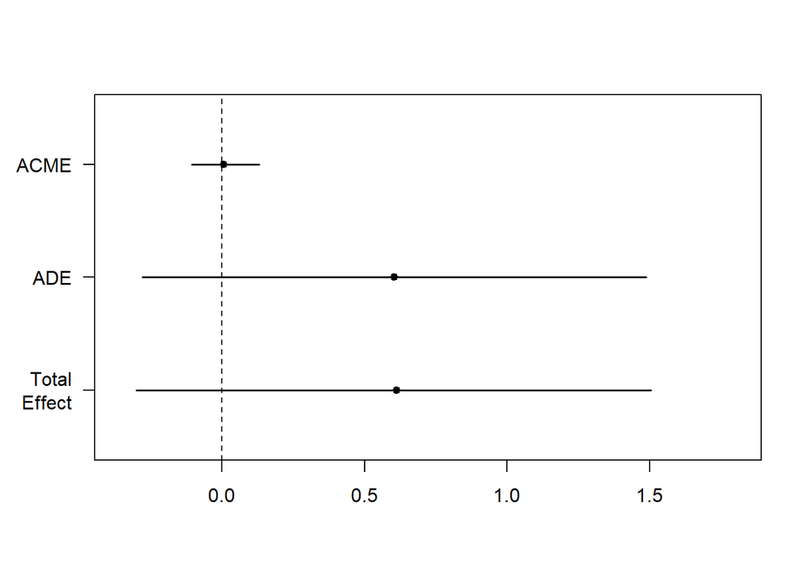

69 multiple-imputed datasets, 1000 simulations each

##### 2.5.1.2.2 Sin PTSD T0 como predictor

```
## [1] "t1_pcl_tot ~ t0_tq + t0_pdeq + t0_age + t0_sex + t0_years_educ + t0_tx\n                + t0_mspss"
```

```
## [1] "t0_pdeq ~ t0_tq + t0_age + t0_sex + t0_years_educ + t0_tx\n                + t0_mspss"
```

```
## Causal Mediation Analysis
##
## Nonparametric Bootstrap Confidence Intervals with the Percentile Method
##
##                Estimate 95% CI Lower 95% CI Upper
## ACME             0.5694       0.2294         0.98
## ADE              2.0664       1.1307         2.97
## Total Effect     2.6358       1.7400         3.53
## Prop. Mediated   0.2228       0.0851         0.41
##
## Sample Size Used: 187
##
##
## Simulations: 1000
```

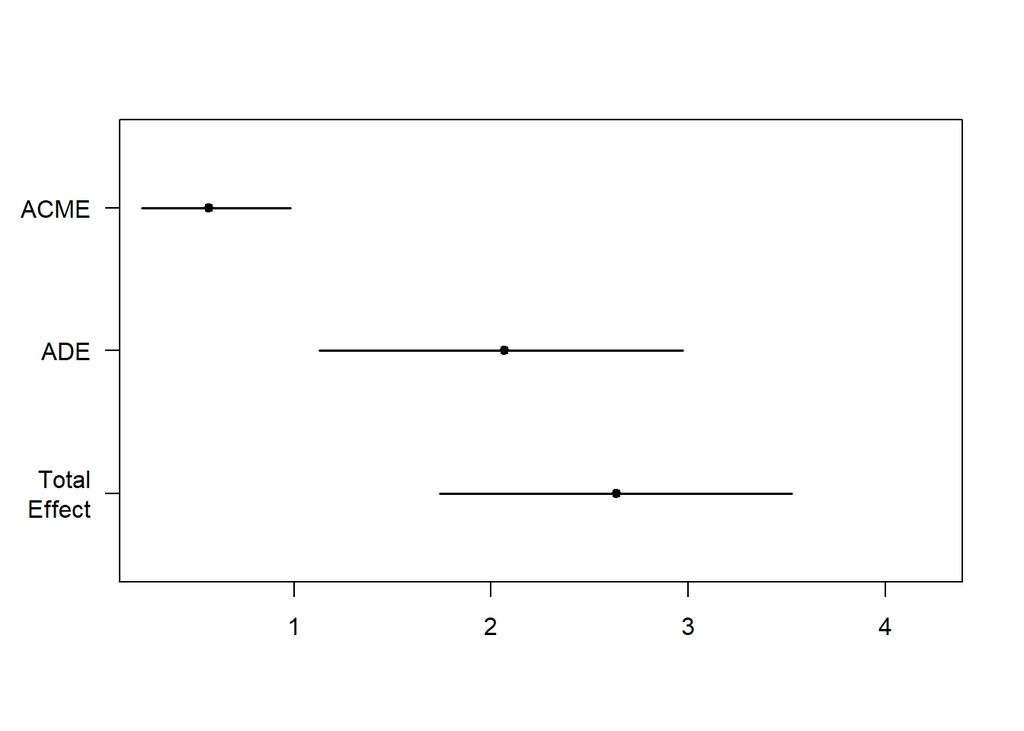

#### 2.5.2.1 Original results

Table 4: Peritraumatic dissociation as a mediator between years of education and PTSD

|  | Estimate | 95% CI Lower | 95% CI Upper | p-value |
| --- | --- | --- | --- | --- |
| ACME | 0.599 | -0.369 | 2.057 | 0.25 |
| ADE | 1.338 | -1.468 | 4.137 | 0.35 |
| Total Effect | 1.936 | -0.978 | 4.762 | 0.18 |
| Prop. Mediated | 0.235 | -1.749 | 3.032 | 0.33 |

Sample Size Used: 57; Simulations: 10000

#### 2.5.2.2 Updated results

##### 2.5.2.2.1 Con PTSD T0 como predictor

```
## [1] "t1_pcl_tot ~ t0_tq + t0_pdi + t0_pcl_tot + t0_age + t0_sex + t0_years_educ + t0_tx + t0_mspss"
```

```
## [1] "t0_pdi ~ t0_tq + t0_pcl_tot + t0_age + t0_sex + t0_years_educ + t0_tx + t0_mspss"
```

[output not shown]

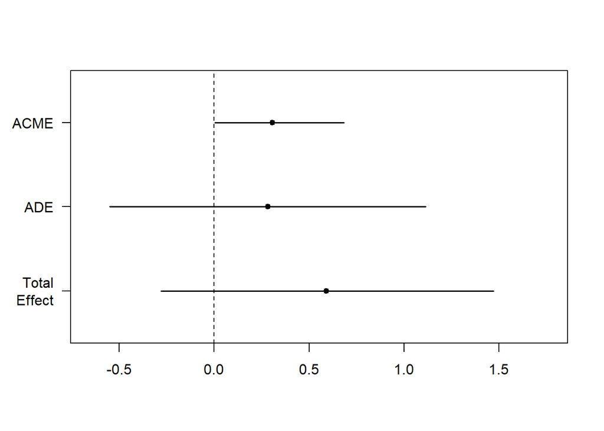

69 multiple-imputed datasets, 1000 simulations each

##### 2.5.2.2.2 Sin PTSD T0 como predictor

```
## [1] "t1_pcl_tot ~ t0_tq + t0_pdi + t0_age + t0_sex + t0_years_educ + t0_tx + t0_mspss"
```

```
## [1] "t0_pdi ~ t0_tq + t0_age + t0_sex + t0_years_educ + t0_tx + t0_mspss"
```

```
## Causal Mediation Analysis
##
## Nonparametric Bootstrap Confidence Intervals with the Percentile Method
##
##                Estimate 95% CI Lower 95% CI Upper
## ACME              0.804        0.379         1.27
## ADE               1.664        0.729         2.63
## Total Effect      2.468        1.510         3.40
## Prop. Mediated    0.339        0.164         0.56
##
## Sample Size Used: 187
##
##
## Simulations: 1000
```

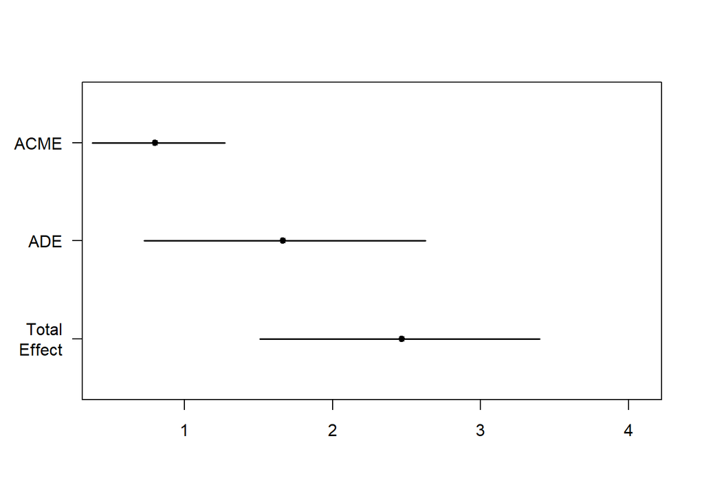

### 2.5.3 Modelos con peritraumatic stress como mediador

##### 2.5.3.1.1 Con PTSD como predictor

```
## [1] "t1_pcl_tot ~ t0_years_educ + t0_pdeq + t0_pcl_tot + t0_age + t0_sex + t0_tx + t0_mspss + t0_tq"
```

```
## [1] "t0_pdeq ~ t0_years_educ + t0_pcl_tot + t0_age + t0_sex + t0_tx + t0_mspss + t0_tq"
```

```
##
## Causal Mediation Analysis
##
## Quasi-Bayesian Confidence Intervals
##
##                Estimate % CI Lower % CI Upper p-value
## ACME             0.0156    -0.0425       0.09       1
## ADE             -0.7147    -1.1905      -0.22       1
## Total Effect    -0.6991    -1.1735      -0.19       1
## Prop. Mediated  -0.0348    -0.1962       0.07       1
##
## Sample Size Used: 187
##
##
## Simulations: 1000
```

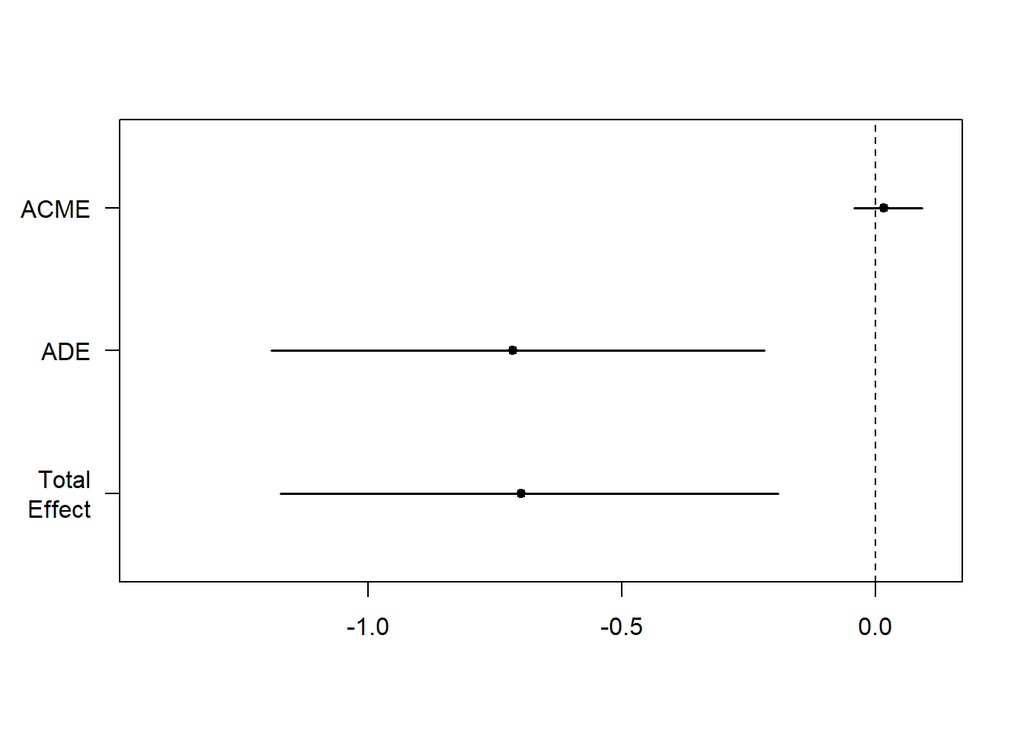

69 multiple-imputed datasets, 1000 simulations each

##### 2.5.3.1.2 Sin PTSD T0 como predictor

```
## [1] "t1_pcl_tot ~ t0_years_educ + t0_pdeq + t0_age + t0_sex + t0_tx + t0_mspss + t0_tq"
```

```
## [1] "t0_pdeq ~ t0_years_educ + t0_age + t0_sex + t0_tx + t0_mspss + t0_tq"
```

```
## Causal Mediation Analysis
##
## Nonparametric Bootstrap Confidence Intervals with the Percentile Method
##
##                Estimate 95% CI Lower 95% CI Upper
## ACME             0.0187      -0.1471         0.18
## ADE             -0.9485      -1.4960        -0.37
## Total Effect    -0.9298      -1.5469        -0.30
## Prop. Mediated  -0.0623      -0.3791         0.15
##
## Sample Size Used: 187
##
##
## Simulations: 1000
```

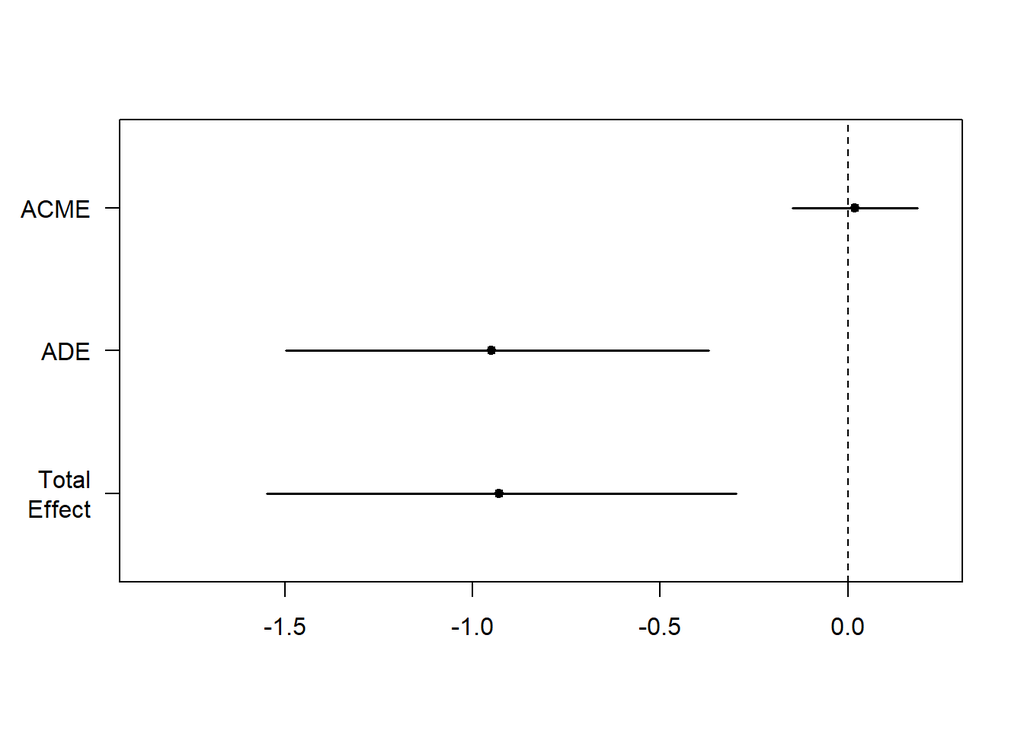

#### 2.5.3.2 Peritraumatic stress as a mediator between years of education and PTSD

##### 2.5.3.2.1 Con PTSD como predictor

```
## [1] "t1_pcl_tot ~ t0_years_educ + t0_pdi + t0_pcl_tot + t0_age + t0_sex + t0_tx + t0_mspss + t0_tq"
```

```
## [1] "t0_pdi ~ t0_years_educ + t0_pcl_tot + t0_age + t0_sex + t0_tx + t0_mspss + t0_tq"
```

```
##
## Causal Mediation Analysis
##
## Quasi-Bayesian Confidence Intervals
##
##                Estimate % CI Lower % CI Upper p-value
## ACME             -0.509     -0.761      -0.29       1
## ADE              -0.198     -0.674       0.27       1
## Total Effect     -0.707     -1.191      -0.20       1
## Prop. Mediated    0.902      0.356       2.00       1
##
## Sample Size Used: 187
##
##
## Simulations: 1000
```

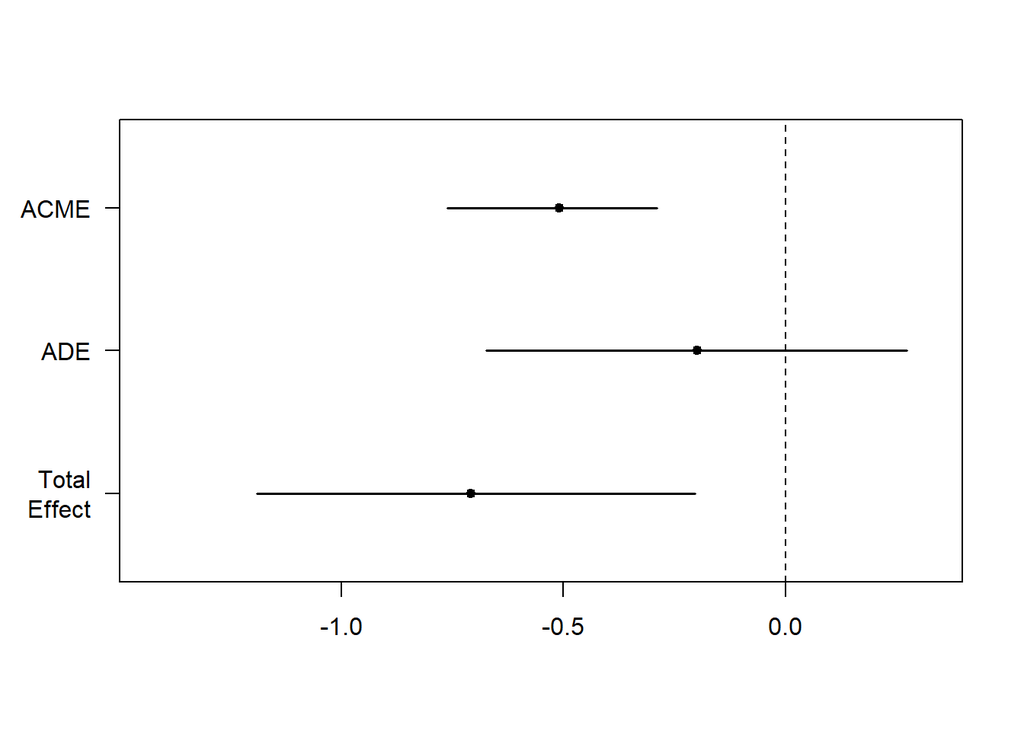

##### 2.5.3.2.2 Sin PTSD T0 como predictor

```
## [1] "t1_pcl_tot ~ t0_years_educ + t0_pdi + t0_age + t0_sex + t0_tx + t0_mspss + t0_tq"
```

```
## [1] "t0_pdi ~ t0_years_educ + t0_age + t0_sex + t0_tx + t0_mspss + t0_tq"
```

```
## Causal Mediation Analysis
##
## Nonparametric Bootstrap Confidence Intervals with the Percentile Method
##
##                Estimate 95% CI Lower 95% CI Upper
## ACME             -0.420       -0.666        -0.20
## ADE              -0.530       -1.124         0.05
## Total Effect     -0.950       -1.582        -0.33
## Prop. Mediated    0.487        0.219         1.02
##
## Sample Size Used: 187
##
##
## Simulations: 1000
```

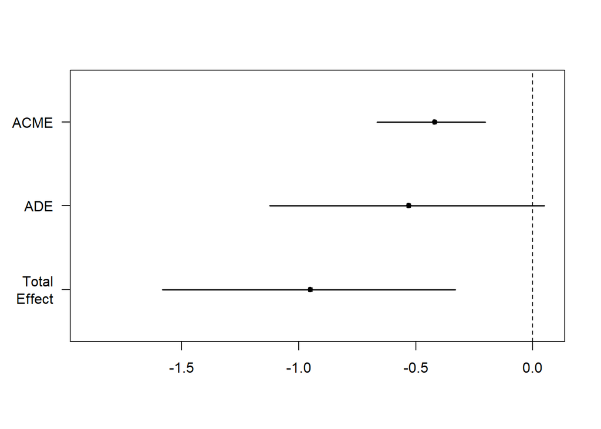

# 3 Discussion

| Original results | Updated results |
| --- | --- |
| This is particularly relevant considering that compared to patients who completed the study, those who abandoned the study between T0 and T1 were significantly more depressed at baseline (p < .05) | p( < .05) |
| and dissociated more during the traumatic experience (p < .01). | (p < .01) |

Welch Two Sample t-test: `t0_bdi` by `t1_sample` (continued below)

| Test statistic | df | P value | Alternative hypothesis |
| --- | --- | --- | --- |
| 2.473 | 350.8 | 0.01388 * | two.sided |

| mean in group FALSE | mean in group TRUE |
| --- | --- |
| 17.8 | 14.81 |

Welch Two Sample t-test: `t0_pdeq` by `t1_sample` (continued below)

| Test statistic | df | P value | Alternative hypothesis |
| --- | --- | --- | --- |
| 3.662 | 357.9 | 0.000288 * * * | two.sided |

| mean in group FALSE | mean in group TRUE |
| --- | --- |
| 27 | 22.68 |